# code draft

```python
# Import libraries
import pandas as pd
import numpy as np
import matplotlib.pyplot as plt
import seaborn as sns
import scipy.optimize as optimize
import scipy.stats as stats
import statsmodels.api as sm
from statsmodels.genmod.families import Poisson

# Set style for plots
print(plt.style.available)  # Print available styles
plt.style.use('seaborn-v0_8-pastel')    # Use a guaranteed style
```

```
['Solarize_Light2', '_classic_test_patch', '_mpl-gallery', '_mpl-gallery-nogrid', 'bmh', 'classic', 'dark_background', 'fast', 'fivethirtyeight', 'ggplot', 'grayscale', 'seaborn-v0_8', 'seaborn-v0_8-bright', 'seaborn-v0_8-colorblind', 'seaborn-v0_8-dark', 'seaborn-v0_8-dark-palette', 'seaborn-v0_8-d…
```

Reading Data

```python
# Read in data
# Read in Blueprinty data
blueprinty = pd.read_csv('/home/jovyan/vvwebsite/blog/homework2/blueprinty.csv')
blueprinty.head()
```

|  | patents | region | age | iscustomer |
| --- | --- | --- | --- | --- |
| 0 | 0 | Midwest | 32.5 | 0 |
| 1 | 3 | Southwest | 37.5 | 0 |
| 2 | 4 | Northwest | 27.0 | 1 |
| 3 | 3 | Northeast | 24.5 | 0 |
| 4 | 3 | Southwest | 37.0 | 0 |

Compare histograms and means of number of patents by customer status. What do you observe?

```
Mean patents for customers: 4.13
Mean patents for non-customers: 3.47
```

[figure not shown]

```python
# Compare histograms and means of number of patents by customer status
customer_patents = blueprinty[blueprinty['iscustomer'] == 1]['patents']
non_customer_patents = blueprinty[blueprinty['iscustomer'] == 0]['patents']

print(f"Mean patents for customers: {customer_patents.mean():.2f}")
print(f"Mean patents for non-customers: {non_customer_patents.mean():.2f}")

# Create histogram
plt.figure(figsize=(10, 6))
sns.histplot(data=blueprinty, x='patents', hue='iscustomer',
             multiple='dodge', kde=True, bins=20)
plt.xlabel('Number of Patents', fontsize=12)
plt.ylabel('Frequency', fontsize=12)
plt.title('Distribution of Patents by Customer Status', fontsize=14)
plt.legend(title='Customer Status', labels=['Non-Customer', 'Customer'])
plt.tight_layout()
plt.show()
```

Compare regions and ages by customer status. What do you observe?

```
Region distribution by customer status (column proportions):
iscustomer         0         1       All
region
Midwest     0.183513  0.076923  0.149333
Northeast   0.267910  0.681913  0.400667
Northwest   0.155054  0.060291  0.124667
South       0.153091  0.072765  0.127333
Southwest   0.240432  0.108108  0.198000
```

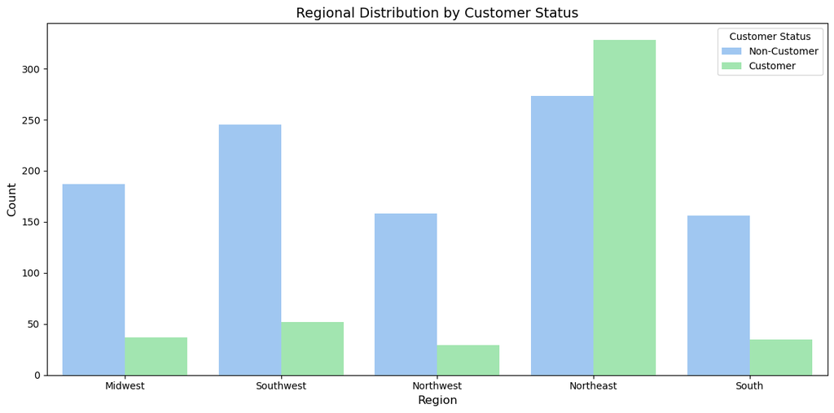

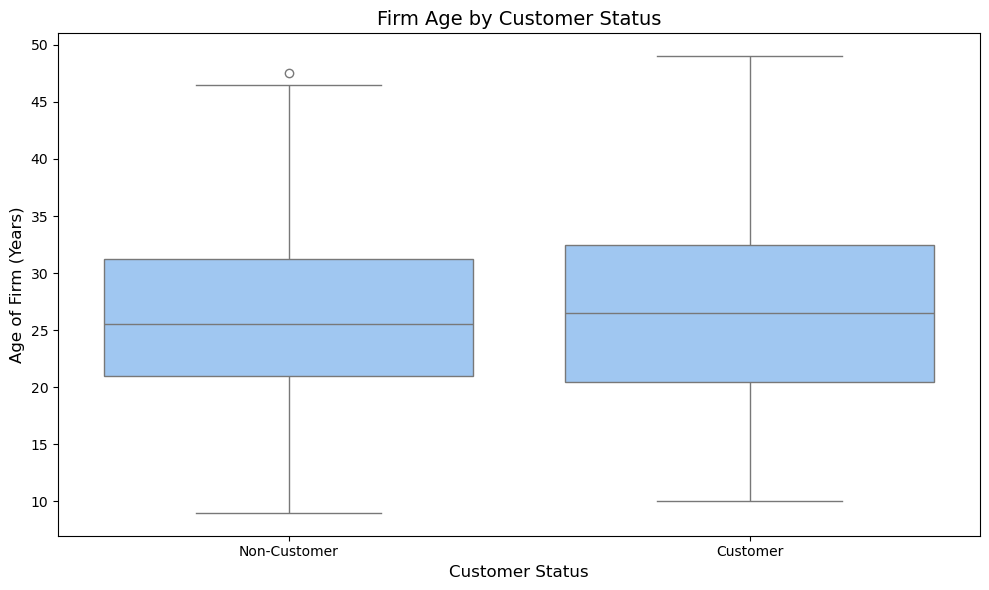

```
Age statistics by customer status:
                 mean       std
iscustomer
0           26.101570  6.945426
1           26.900208  7.814678
```

```python
# Region by customer status
region_customer = pd.crosstab(blueprinty['region'], blueprinty['iscustomer'],
                             normalize='columns', margins=True)
print("Region distribution by customer status (column proportions):")
print(region_customer)

# Plot region distribution
plt.figure(figsize=(12, 6))
sns.countplot(x='region', hue='iscustomer', data=blueprinty)
plt.xlabel('Region', fontsize=12)
plt.ylabel('Count', fontsize=12)
plt.title('Regional Distribution by Customer Status', fontsize=14)
plt.legend(title='Customer Status', labels=['Non-Customer', 'Customer'])
plt.tight_layout()
plt.show()

# Age by customer status
plt.figure(figsize=(10, 6))
sns.boxplot(x='iscustomer', y='age', data=blueprinty)
plt.xlabel('Customer Status', fontsize=12)
plt.xticks([0, 1], ['Non-Customer', 'Customer'])
plt.ylabel('Age of Firm (Years)', fontsize=12)
plt.title('Firm Age by Customer Status', fontsize=14)
plt.tight_layout()
plt.show()

# Calculate mean and std of age by customer status
age_stats = blueprinty.groupby('iscustomer')['age'].agg(['mean', 'std'])
print("\nAge statistics by customer status:")
print(age_stats)
```

Write down mathematically the likelihood for $Y \sim \text{Poisson}(\lambda)$. Note that $f(Y|\lambda) = e^{-\lambda}\lambda^Y/Y!$. For example:

```
poisson_loglikelihood <- function(lambda, Y){
   ...
}
```

```python
def poisson_loglikelihood(lambda_val, Y):
    """
    Compute the log-likelihood for a Poisson distribution.

    Parameters:
    lambda_val (float): The rate parameter for the Poisson distribution
    Y (array): The observed count data

    Returns:
    float: The log-likelihood value
    """
    # Poisson log-likelihood: sum(-lambda + y*log(lambda) - log(y!))
    # Since log(y!) is constant with respect to lambda, we can omit it for optimization
    return np.sum(-lambda_val + Y * np.log(lambda_val))
```

Use your function to plot lambda on the horizontal axis and the likelihood (or log-likelihood) on the vertical axis for a range of lambdas (use the observed number of patents as the input for Y).

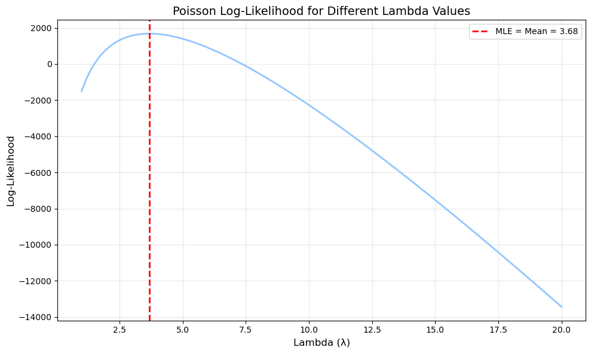

```python
# Get observed patent counts
Y = blueprinty['patents'].values

# Create a range of lambda values
lambda_range = np.linspace(1, 20, 100)

# Calculate log-likelihood for each lambda
loglik_values = [poisson_loglikelihood(lam, Y) for lam in lambda_range]

# Plot the log-likelihood curve
plt.figure(figsize=(10, 6))
plt.plot(lambda_range, loglik_values, linewidth=2)
plt.axvline(x=Y.mean(), color='red', linestyle='--', linewidth=2,
            label=f'MLE = Mean = {Y.mean():.2f}')
plt.xlabel('Lambda (λ)', fontsize=12)
plt.ylabel('Log-Likelihood', fontsize=12)
plt.title('Poisson Log-Likelihood for Different Lambda Values', fontsize=14)
plt.legend()
plt.grid(True, alpha=0.3)
plt.tight_layout()
plt.show()
```

If you're feeling mathematical, take the first derivative of your likelihood or log-likelihood, set it equal to zero and solve for lambda. You will find lambda_mle is Ybar, which "feels right" because the mean of a Poisson distribution is lambda.

Find the MLE by optimizing your likelihood function with optim() in R or sp.optimize() in Python.

```python
# Get observed patent counts
Y = blueprinty['patents'].values

# Function to minimize (negative log-likelihood)
def neg_loglikelihood(lambda_val):
    return -poisson_loglikelihood(lambda_val, Y)

# Optimize to find MLE
result = optimize.minimize_scalar(neg_loglikelihood, bounds=(0.1, 30), method='bounded')

print(f"Mean of observed patents (Y): {Y.mean():.4f}")
print(f"MLE of lambda using optimization: {result.x:.4f}")
print(f"Maximum log-likelihood value: {-result.fun:.4f}")
```

```
Mean of observed patents (Y): 3.6847
MLE of lambda using optimization: 3.6847
Maximum log-likelihood value: 1681.2032
```

Update your likelihood or log-likelihood function with an additional argument to take in a covariate matrix X. Also change the parameter of the model from lambda to the beta vector. In this model, lambda must be a positive number, so we choose the inverse link function g_inv() to be exp() so that $\lambda_i = e^{X_i'\beta}$. For example:

```
poisson_regression_likelihood <- function(beta, Y, X){
   ...
}
```

```python
def poisson_regression_loglikelihood(beta, Y, X):
    """
    Compute the log-likelihood for a Poisson regression model.

    Parameters:
    beta (array): The regression coefficients
    Y (array): The observed count data
    X (array): The covariate matrix

    Returns:
    float: The log-likelihood value
    """
    # Ensure inputs are numpy arrays
    X = np.asarray(X)
    Y = np.asarray(Y)

    # Calculate lambda_i = exp(X_i * beta) for each observation
    XB = np.dot(X, beta)  # Matrix multiplication
    lambda_values = np.exp(XB)

    # Calculate log-likelihood
    # Handle potential numerical issues
    log_lambda = np.log(np.maximum(lambda_values, 1e-10))
    log_likelihood = np.sum(-lambda_values + Y * log_lambda)

    return log_likelihood
```

Use your function along with R's optim() or Python's sp.optimize() to find the MLE vector and the Hessian of the Poisson model with covariates. Specifically, the first column of X should be all 1's to enable a constant term in the model, and the subsequent columns should be age, age squared, binary variables for all but one of the regions, and the binary customer variable. Use the Hessian to find standard errors of the beta parameter estimates and present a table of coefficients and standard errors.

```python
# Prepare data for regression - with data type checking and conversion
# First, examine blueprinty data types
print("Column types before conversion:")
print(blueprinty.dtypes)

# Create age squared
blueprinty['age_squared'] = blueprinty['age'] ** 2

# Convert all numeric columns to float (handle any potential objects)
numeric_cols = ['patents', 'age', 'age_squared']
for col in numeric_cols:
    blueprinty[col] = pd.to_numeric(blueprinty[col], errors='coerce')

# Make sure the customer column is numeric
customer_col = 'iscustomer'  # adjust if your column has a different name
blueprinty[customer_col] = pd.to_numeric(blueprinty[customer_col], errors='coerce')

# Check for NaN values after conversion
print("\nMissing values after conversion:")
print(blueprinty[numeric_cols + [customer_col]].isna().sum())

# Create dummy variables for regions (omitting one as reference)
region_dummies = pd.get_dummies(blueprinty['region'], prefix='region', drop_first=True)

# Create final dataset - only include rows with complete data
complete_data = blueprinty.dropna(subset=numeric_cols + [customer_col])
print(f"\nRows with complete data: {len(complete_data)} of {len(blueprinty)}")

# Combine features - only using numeric columns
X = pd.concat([
    region_dummies.loc[complete_data.index],
    complete_data[['age', 'age_squared', customer_col]]
], axis=1)

# Make sure all data is properly typed
X = X.astype(float)

# Add constant term
X = sm.add_constant(X)

# Response variable
Y = complete_data['patents'].astype(float)

# Fit Poisson regression model
model = sm.GLM(Y, X, family=sm.families.Poisson())
results = model.fit()

# Create a nice coefficient table
coef_table = pd.DataFrame({
    'Variable': X.columns,
    'Coefficient': results.params,
    'Std.Err': results.bse,
    'z-value': results.tvalues,
    'p-value': results.pvalues,
    'IRR': np.exp(results.params)  # Incidence Rate Ratio for interpretation
})

print("\nPoisson Regression Results:")
print(coef_table)

# Store the model for later use in calculating effects
beta_mle = results.params
```

```
Column types before conversion:
patents          int64
region          object
age            float64
iscustomer       int64
age_squared    float64
dtype: object

Missing values after conversion:
patents        0
age            0
age_squared    0
iscustomer     0
dtype: int64

Rows with complete data: 1500 of 1500

Poisson Regression Results:
                          Variable  Coefficient   Std.Err    z-value  \
const                        const    -0.508920  0.183179  -2.778269
region_Northeast  region_Northeast     0.029170  0.043625   0.668647
region_Northwest  region_Northwest    -0.017575  0.053781  -0.326782
region_South          region_South     0.056561  0.052662   1.074036
region_Southwest  region_Southwest     0.050576  0.047198   1.071568
age                            age     0.148619  0.013869  10.716250
age_squared            age_squared    -0.002970  0.000258 -11.513237
iscustomer              iscustomer     0.207591  0.030895   6.719179

                       p-value       IRR
const             5.464935e-03  0.601145
region_Northeast  5.037205e-01  1.029600
region_Northwest  7.438327e-01  0.982579
region_South      2.828066e-01  1.058191
region_Southwest  2.839141e-01  1.051877
age               8.539597e-27  1.160231
age_squared       1.131496e-30  0.997034
iscustomer        1.827509e-11  1.230709
```

Check your results using R's glm() function or Python sm.GLM() function.

```python
# Fit GLM with Poisson family
model = sm.GLM(Y, X, family=sm.families.Poisson())
results = model.fit()

print("\nPoisson Regression Results (using statsmodels GLM):")
print(results.summary())

# Create a clean coefficient table
coef_df = pd.DataFrame({
    'Variable': results.model.exog_names,
    'Coefficient': results.params,
    'Std.Err': results.bse,
    'z-value': results.tvalues,
    'p-value': results.pvalues
})

coef_df
```

```
Poisson Regression Results (using statsmodels GLM):
                 Generalized Linear Model Regression Results
==============================================================================
Dep. Variable:                patents   No. Observations:                 1500
Model:                            GLM   Df Residuals:                     1492
Model Family:                 Poisson   Df Model:                            7
Link Function:                    Log   Scale:                          1.0000
Method:                          IRLS   Log-Likelihood:                -3258.1
Date:                Wed, 30 Apr 2025   Deviance:                       2143.3
Time:                        20:34:59   Pearson chi2:                 2.07e+03
No. Iterations:                     5   Pseudo R-squ. (CS):             0.1360
Covariance Type:            nonrobust
====================================================================================
                       coef    std err          z      P>|z|      [0.025      0.975]
------------------------------------------------------------------------------------
const               -0.5089      0.183     -2.778      0.005      -0.868      -0.150
region_Northeast     0.0292      0.044      0.669      0.504      -0.056       0.115
region_Northwest    -0.0176      0.054     -0.327      0.744      -0.123       0.088
region_South         0.0566      0.053      1.074      0.283      -0.047       0.160
region_Southwest     0.0506      0.047      1.072      0.284      -0.042       0.143
age                  0.1486      0.014     10.716      0.000       0.121       0.176
age_squared         -0.0030      0.000    -11.513      0.000      -0.003      -0.002
iscustomer           0.2076      0.031      6.719      0.000       0.147       0.268
====================================================================================
```

|  | Variable | Coefficient | Std.Err | z-value | p-value |
| --- | --- | --- | --- | --- | --- |
| const | const | -0.508920 | 0.183179 | -2.778269 | 5.464935e-03 |
| region_Northeast | region_Northeast | 0.029170 | 0.043625 | 0.668647 | 5.037205e-01 |
| region_Northwest | region_Northwest | -0.017575 | 0.053781 | -0.326782 | 7.438327e-01 |
| region_South | region_South | 0.056561 | 0.052662 | 1.074036 | 2.828066e-01 |
| region_Southwest | region_Southwest | 0.050576 | 0.047198 | 1.071568 | 2.839141e-01 |
| age | age | 0.148619 | 0.013869 | 10.716250 | 8.539597e-27 |
| age_squared | age_squared | -0.002970 | 0.000258 | -11.513237 | 1.131496e-30 |
| iscustomer | iscustomer | 0.207591 | 0.030895 | 6.719179 | 1.827509e-11 |

Interpret the results.

What do you conclude about the effect of Blueprinty's software on patent success? Because the beta coefficients are not directly interpretable, it may help to create two fake datasets: X_0 and X_1 where X_0 is the X data but with iscustomer=0 for every observation and X_1 is the X data but with iscustomer=1 for every observation. Then, use X_0 and your fitted model to get the vector of predicted number of patents (y_pred_0) for every firm in the dataset, and use X_1 to get Y_pred_1 for every firm. Then subtract y_pred_1 minus y_pred_0 and take the average of that vector of differences.

```
Effect of Blueprinty's Software on Number of Patents:
Mean increase in patents: 0.7928
Median increase in patents: 0.8382
```

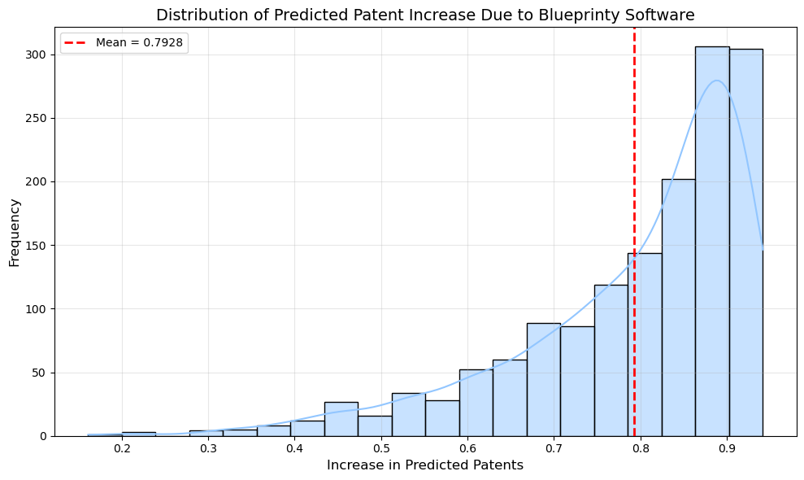

```python
# Create two datasets: X_0 (all non-customers) and X_1 (all customers)
X_0 = X.copy()
X_1 = X.copy()

# Set customer status
X_0['iscustomer'] = 0
X_1['iscustomer'] = 1

# Calculate predicted lambda values using statsmodels results
# (more reliable than using the manual optimization results)
lambda_0 = np.exp(np.dot(X_0, results.params))
lambda_1 = np.exp(np.dot(X_1, results.params))

# Calculate differences in predicted patents
differences = lambda_1 - lambda_0

# Calculate mean difference
mean_difference = np.mean(differences)
median_difference = np.median(differences)

print("\nEffect of Blueprinty's Software on Number of Patents:")
print(f"Mean increase in patents: {mean_difference:.4f}")
print(f"Median increase in patents: {median_difference:.4f}")

# Show histogram of differences
plt.figure(figsize=(10, 6))
sns.histplot(differences, bins=20, kde=True)
plt.axvline(x=mean_difference, color='red', linestyle='--', linewidth=2,
            label=f'Mean = {mean_difference:.4f}')
plt.xlabel('Increase in Predicted Patents', fontsize=12)
plt.ylabel('Frequency', fontsize=12)
plt.title('Distribution of Predicted Patent Increase Due to Blueprinty Software',
          fontsize=14)
plt.legend()
plt.grid(True, alpha=0.3)
plt.tight_layout()
plt.show()
```

For AirBnb

```
Initial data shape: (40628, 14)

Column data types:
Unnamed: 0                     int64
id                             int64
days                           int64
last_scraped                  object
host_since                    object
room_type                     object
bathrooms                    float64
bedrooms                     float64
price                          int64
number_of_reviews              int64
review_scores_cleanliness    float64
review_scores_location       float64
review_scores_value          float64
instant_bookable              object
dtype: object

Missing Values Summary:
                           Missing Values    Percent
review_scores_value                 10256  25.243674
review_scores_location              10254  25.238752
review_scores_cleanliness           10195  25.093532
bathrooms                             160   0.393817
bedrooms                               76   0.187063
host_since                             35   0.086147

Rows after cleaning essential variables: 40395 of 40628
Rows with complete review scores: 30160 of 40395
```

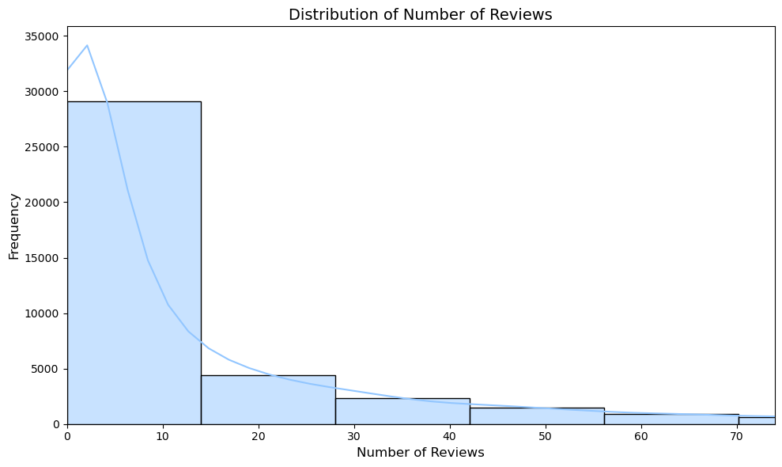

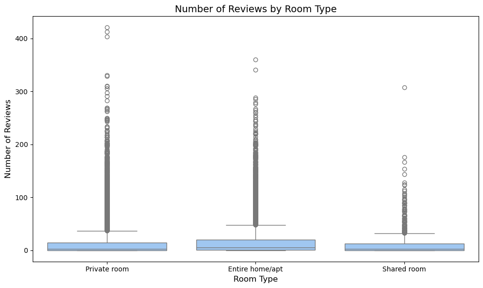

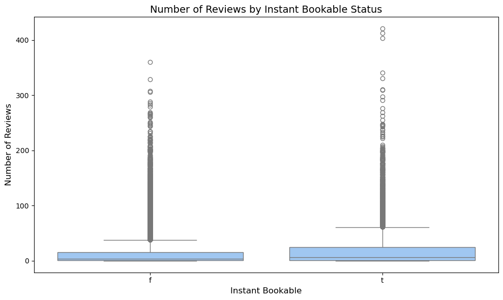

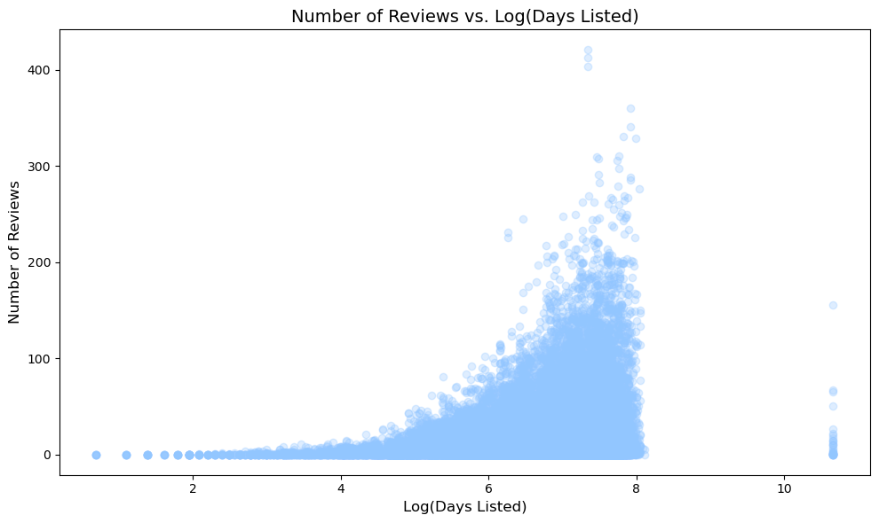

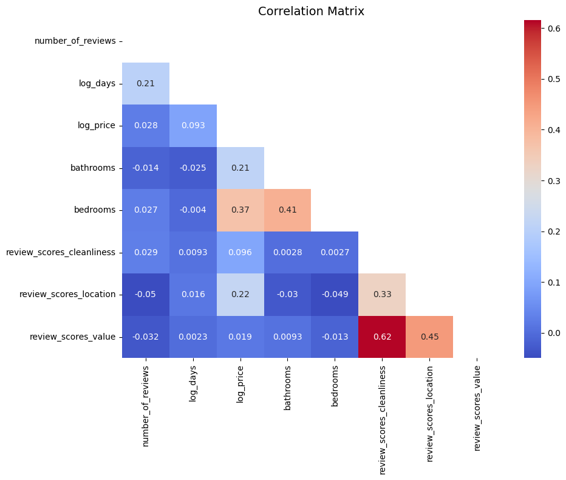

```
Data types for model variables:
const                      float64
log_days                   float64
log_price                  float64
bathrooms                  float64
bedrooms                   float64
instant_bookable_binary    float64
room_Private room          float64
room_Shared room           float64
dtype: object
Response variable dtype: float64

Poisson Regression Model 1 (Without Review Scores):
                 Generalized Linear Model Regression Results
==============================================================================
Dep. Variable:      number_of_reviews   No. Observations:                40395
Model:                            GLM   Df Residuals:                    40387
Model Family:                 Poisson   Df Model:                            7
Link Function:                    Log   Scale:                          1.0000
Method:                          IRLS   Log-Likelihood:            -6.5515e+05
Date:                Wed, 30 Apr 2025   Deviance:                   1.1871e+06
Time:                        20:46:46   Pearson chi2:                 1.71e+06
No. Iterations:                     6   Pseudo R-squ. (CS):             0.9693
Covariance Type:            nonrobust
===========================================================================================
                              coef    std err          z      P>|z|      [0.025      0.975]
-------------------------------------------------------------------------------------------
const                      -1.0479      0.018    -58.050      0.000      -1.083      -1.012
log_days                    0.5781      0.002    331.573      0.000       0.575       0.581
log_price                  -0.0440      0.003    -16.256      0.000      -0.049      -0.039
bathrooms                  -0.1204      0.004    -31.702      0.000      -0.128      -0.113
bedrooms                    0.0908      0.002     44.488      0.000       0.087       0.095
instant_bookable_binary     0.5562      0.003    191.175      0.000       0.550       0.562
room_Private room          -0.0961      0.003    -29.185      0.000      -0.103      -0.090
room_Shared room           -0.2358      0.009    -26.185      0.000      -0.253      -0.218
===========================================================================================

Poisson Regression Model 2 (With Review Scores):
                 Generalized Linear Model Regression Results
==============================================================================
```

[output cut: 9 more lines]

```
=============================================================================================
                                coef    std err          z      P>|z|      [0.025      0.975]
---------------------------------------------------------------------------------------------
const                        -0.2618      0.023    -11.207      0.000      -0.308      -0.216
log_days                      0.5034      0.002    274.842      0.000       0.500       0.507
log_price                     0.0884      0.003     29.828      0.000       0.083       0.094
bathrooms                    -0.1278      0.004    -33.818      0.000      -0.135      -0.120
bedrooms                      0.0606      0.002     29.115      0.000       0.057       0.065
instant_bookable_binary       0.4960      0.003    169.848      0.000       0.490       0.502
review_scores_cleanliness     0.1100      0.002     72.394      0.000       0.107       0.113
review_scores_location       -0.0946      0.002    -56.624      0.000      -0.098      -0.091
review_scores_value          -0.0843      0.002    -45.107      0.000      -0.088      -0.081
room_Private room             0.0818      0.003     24.200      0.000       0.075       0.088
room_Shared room             -0.0237      0.009     -2.607      0.009      -0.042      -0.006
=============================================================================================
```

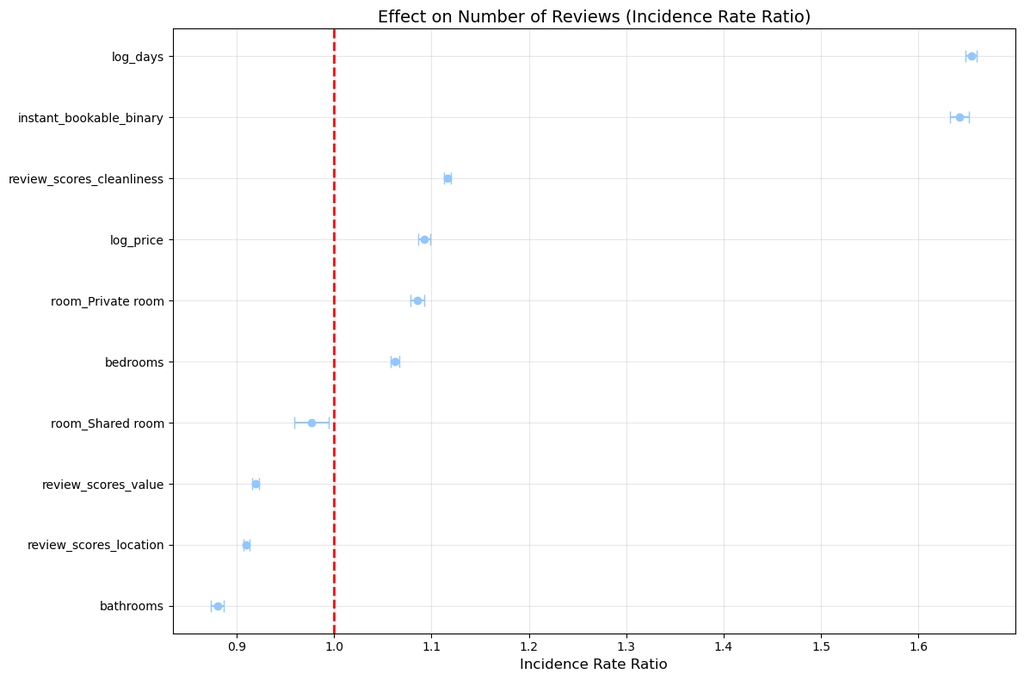

```
Incidence Rate Ratios (sorted by magnitude):
                                            Variable       IRR  IRR_CI_Lower  \
log_days                                    log_days  1.654281      1.648354
instant_bookable_binary      instant_bookable_binary  1.642166      1.632793
review_scores_cleanliness  review_scores_cleanliness  1.116302      1.112982
log_price                                  log_price  1.092395      1.086070
room_Private room                  room_Private room  1.085194      1.078032
bedrooms                                    bedrooms  1.062527      1.058197
room_Shared room                    room_Shared room  0.976541      0.959269
review_scores_value              review_scores_value  0.919169      0.915809
review_scores_location        review_scores_location  0.909731      0.906757
bathrooms                                  bathrooms  0.880064      0.873572
const                                          const  0.769672      0.735227

                           IRR_CI_Upper        p-value
log_days                       1.660230   0.000000e+00
instant_bookable_binary        1.651593   0.000000e+00
review_scores_cleanliness      1.119632   0.000000e+00
log_price                      1.098757  1.712634e-195
room_Private room              1.092404  2.234887e-129
bedrooms                       1.066874  2.348203e-186
room_Shared room               0.994124   9.125784e-03
review_scores_value            0.922541   0.000000e+00
review_scores_location         0.912715   0.000000e+00
bathrooms                      0.886605  1.074253e-250
const                          0.805731   3.775047e-29
```

```python
# Read in AirBnB data
airbnb = pd.read_csv('/home/jovyan/vvwebsite/blog/homework2/airbnb.csv')

# Initial data inspection
print("Initial data shape:", airbnb.shape)
print("\nColumn data types:")
print(airbnb.dtypes)

# Check missing values
missing_values = airbnb.isnull().sum().sort_values(ascending=False)
missing_percent = (missing_values / len(airbnb)) * 100
missing_df = pd.DataFrame({'Missing Values': missing_values, 'Percent': missing_percent})
print("\nMissing Values Summary:")
print(missing_df[missing_df['Missing Values'] > 0])

# Data preparation with explicit type conversion
# Convert numeric columns to proper types
numeric_cols = ['number_of_reviews', 'days', 'price', 'bathrooms', 'bedrooms',
                'review_scores_cleanliness', 'review_scores_location', 'review_scores_value']

# Create a clean copy for processing
airbnb_processed = airbnb.copy()

# Convert all numerics with error handling
for col in numeric_cols:
    if col in airbnb_processed.columns:
        airbnb_processed[col] = pd.to_numeric(airbnb_processed[col], errors='coerce')

# Create log transformations of key variables
airbnb_processed['log_days'] = np.log1p(airbnb_processed['days'])
airbnb_processed['log_price'] = np.log1p(airbnb_processed['price'])

# Convert instant_bookable to numeric
airbnb_processed['instant_bookable_binary'] = (airbnb_processed['instant_bookable'] == 't').astype(int)

# Drop rows with missing values in key modeling variables
model_vars = ['number_of_reviews', 'days', 'room_type', 'bathrooms', 'bedrooms',
             'price', 'instant_bookable_binary']

# Clean dataset for initial model (without review scores)
airbnb_clean = airbnb_processed.dropna(subset=model_vars)
print(f"\nRows after cleaning essential variables: {len(airbnb_clean)} of {len(airbnb)}")

# For models with review scores, create a separate dataset
review_score_vars = ['review_scores_cleanliness', 'review_scores_location', 'review_scores_value']
airbnb_with_scores = airbnb_clean.dropna(subset=review_score_vars)
print(f"Rows with complete review scores: {len(airbnb_with_scores)} of {len(airbnb_clean)}")

# Exploratory Data Analysis
# Distribution of number of reviews
plt.figure(figsize=(10, 6))
sns.histplot(airbnb_clean['number_of_reviews'], bins=30, kde=True)
plt.xlabel('Number of Reviews', fontsize=12)
plt.ylabel('Frequency', fontsize=12)
plt.title('Distribution of Number of Reviews', fontsize=14)
plt.xlim(0, airbnb_clean['number_of_reviews'].quantile(0.95))  # Limit x-axis for better visibility
plt.tight_layout()
plt.show()

# Distribution by room type
plt.figure(figsize=(10, 6))
sns.boxplot(x='room_type', y='number_of_reviews', data=airbnb_clean)
plt.xlabel('Room Type', fontsize=12)
plt.ylabel('Number of Reviews', fontsize=12)
plt.title('Number of Reviews by Room Type', fontsize=14)
plt.tight_layout()
plt.show()

# Distribution by instant bookable
plt.figure(figsize=(10, 6))
sns.boxplot(x='instant_bookable', y='number_of_reviews', data=airbnb_clean)
plt.xlabel('Instant Bookable', fontsize=12)
plt.ylabel('Number of Reviews', fontsize=12)
plt.title('Number of Reviews by Instant Bookable Status', fontsize=14)
plt.tight_layout()
plt.show()

# Relationship with listing age (days)
plt.figure(figsize=(10, 6))
plt.scatter(airbnb_clean['log_days'], airbnb_clean['number_of_reviews'], alpha=0.3)
plt.xlabel('Log(Days Listed)', fontsize=12)
plt.ylabel('Number of Reviews', fontsize=12)
plt.title('Number of Reviews vs. Log(Days Listed)', fontsize=14)
plt.tight_layout()
plt.show()

# Correlation matrix for numerical variables
if len(airbnb_with_scores) > 0:  # Only if we have data with review scores
    numeric_vars = ['number_of_reviews', 'log_days', 'log_price', 'bathrooms', 'bedrooms',
                    'review_scores_cleanliness', 'review_scores_location', 'review_scores_value']

    # Make sure all columns exist and are numeric
    existing_vars = [var for var in numeric_vars if var in airbnb_with_scores.columns]
    corr_data = airbnb_with_scores[existing_vars].copy()

    plt.figure(figsize=(10, 8))
    corr_matrix = corr_data.corr()
    mask = np.triu(corr_matrix)
    sns.heatmap(corr_matrix, annot=True, cmap='coolwarm', mask=mask)
    plt.title('Correlation Matrix', fontsize=14)
    plt.tight_layout()
    plt.show()

# MODEL 1: Basic predictors without review scores
# Prepare data for modeling with careful type handling
y = airbnb_clean['number_of_reviews'].astype(float)

# Create dummy variables for room_type
room_dummies = pd.get_dummies(airbnb_clean['room_type'], prefix='room', drop_first=True)
room_dummies = room_dummies.astype(float)  # Ensure numeric type

# Define predictor variables and ensure they are numeric
X1_vars = ['log_days', 'log_price', 'bathrooms', 'bedrooms', 'instant_bookable_binary']
X1_data = airbnb_clean[X1_vars].astype(float)

# Combine predictors
X1 = pd.concat([X1_data, room_dummies], axis=1)
X1 = sm.add_constant(X1)

# Verify there are no object dtypes left
print("\nData types for model variables:")
print(X1.dtypes)
print(f"Response variable dtype: {y.dtype}")

# Fit Poisson regression model
model1 = sm.GLM(y, X1, family=sm.families.Poisson())
results1 = model1.fit()
print("\nPoisson Regression Model 1 (Without Review Scores):")
print(results1.summary())

# MODEL 2: Including review scores (if we have sufficient data)
if len(airbnb_with_scores) > 0:
    # Prepare data with the same careful type handling
    y2 = airbnb_with_scores['number_of_reviews'].astype(float)

    # Create dummy variables
    room_dummies2 = pd.get_dummies(airbnb_with_scores['room_type'], prefix='room', drop_first=True)
    room_dummies2 = room_dummies2.astype(float)

    # Ensure all predictors are numeric
    X2_vars = ['log_days', 'log_price', 'bathrooms', 'bedrooms',
              'instant_bookable_binary', 'review_scores_cleanliness',
              'review_scores_location', 'review_scores_value']
    X2_data = airbnb_with_scores[X2_vars].astype(float)

    # Combine predictors
    X2 = pd.concat([X2_data, room_dummies2], axis=1)
    X2 = sm.add_constant(X2)

    # Fit model
    model2 = sm.GLM(y2, X2, family=sm.families.Poisson())
    results2 = model2.fit()
    print("\nPoisson Regression Model 2 (With Review Scores):")
    print(results2.summary())

    # Calculate and plot Incidence Rate Ratios (IRR) for interpretation
    irr2 = pd.DataFrame({
        'Variable': X2.columns,
        'Coefficient': results2.params,
        'IRR': np.exp(results2.params),
        'IRR_CI_Lower': np.exp(results2.params - 1.96 * results2.bse),
        'IRR_CI_Upper': np.exp(results2.params + 1.96 * results2.bse),
        'p-value': results2.pvalues
    })

    # Sort by magnitude (exclude intercept)
    irr_plot = irr2.iloc[1:].sort_values('IRR').copy()

    # Create IRR plot
    plt.figure(figsize=(12, 8))
    plt.errorbar(
        irr_plot['IRR'],
        range(len(irr_plot)),
        xerr=[irr_plot['IRR'] - irr_plot['IRR_CI_Lower'],
              irr_plot['IRR_CI_Upper'] - irr_plot['IRR']],
        fmt='o',
        capsize=5
    )

    plt.axvline(x=1, color='red', linestyle='--', linewidth=2,
                label='No Effect (IRR=1)')
    plt.yticks(range(len(irr_plot)), irr_plot['Variable'])
    plt.xlabel('Incidence Rate Ratio', fontsize=12)
    plt.title('Effect on Number of Reviews (Incidence Rate Ratio)',
              fontsize=14)
    plt.grid(True, alpha=0.3)
    plt.tight_layout()
    plt.show()

    # Display IRR table for interpretation
    irr_sorted = irr2.sort_values('IRR', ascending=False)
    print("\nIncidence Rate Ratios (sorted by magnitude):")
    print(irr_sorted[['Variable', 'IRR', 'IRR_CI_Lower', 'IRR_CI_Upper', 'p-value']])
```